# Forecasting epidemic trajectories: Time Series Growth Curves package `tsgc`

Michael Ashby, Andrew Harvey, Paul Kattuman, Craig Thamotheram

2026-07-04

Abstract

This paper documents the Time Series Growth Curves (`tsgc`) package for `R`, which is designed for forecasting epidemic trajectories, including the detection of new waves and turning points. The package implements dynamic Gompertz state-space methods and is illustrated with COVID-19 confirmed cases, hospitalisation data, and non-epidemic applications such as the diffusion of new products and the adoption of online services. The models are estimated with Kalman-filter techniques and are suitable for short-horizon forecasting of variables whose cumulative form is subject to an unknown saturation level.

# Introduction

Outbreaks of infectious diseases with epidemic potential require real-time responses by public health authorities. Accurate real-time forecasting of the trajectory of the epidemic over the near future is of great value in this regard.

The `R` package, `tsgc`, is intended for use in monitoring and forecasting the progress of an epidemic, including the detection of *new waves* and *turning points*. It develops and implements time series growth curve methods first reported in Harvey and Kattuman (2020) (hereinafter referred to as HK). HK develop a class of time series models for predicting future values of a variable which, when cumulated, is subject to an unknown saturation level. In a single wave of an epidemic, as more and more people get infected, the pool of susceptible individuals dwindles. This results in the decline of new infections, and the cumulative number of infections approaches its saturation level. The model can take account of deviations relative to this canonical trajectory due to changes in social behavior and policy. Models in this family are relevant for many other disciplines, such as marketing (when estimating the demand for new products). While attention here is focused on the spread of epidemics and the applications used for illustration relate to coronavirus, this package is designed with a view to wider applicability.

Given the number of different modeling approaches for epidemics, there are many notable packages that can be used for monitoring epidemics. For the most part, these seek to model explicitly the mechanism by which the disease spreads through the population. For example, `EpiModel` (Jenness, Goodreau, and Morris 2018), `EpiEstim` (Cori et al. 2013), `epinowcast` (Abbott and Monticone 2021) to name a few, can be categorized as belonging to the class of *mechanistic* models in the language of philosophy of science, in that they require structural knowledge of the disease spread mechanism in order to obtain predictions.

In contrast, the empirical approach implemented in `tsgc` falls into the class of models described as *phenomenological*. Although it is motivated by the archetypal pattern in the dynamics of disease spread, it does not rely on structural assumptions derived from epidemiological theory. There are advantages to not requiring assumptions about values of parameters relating to, inter alia, disease infectiousness, disease severity, or contact patterns, which are difficult to pin down with sufficient precision, especially in real-time during an epidemic. Our approach makes minimal assumptions and merely requires past observations of the epidemic variable of interest, to which we apply time-series methods to provide predictions over short future time horizons. The model can be estimated quickly and straightforwardly, and subjected to standard diagnostic tests. A statistical model of this type is a useful complement to mechanistic models that attempt to describe the epidemic in terms of underlying processes.

# Theory

## Gompertz curve

Our model is based on the sigmoidal growth curve pattern that characterizes epidemics. We start by assuming that the cumulative number of cases follows a Gompertz curve, which is a parsimonious model for the canonical sigmoid shape of cumulative case numbers in a one-wave epidemic. Over the course of a wave, the number of new infected cases increases up to a peak before declining to zero as the pool of susceptible individuals declines. Specifically, if the cumulative number of cases at time $t$, $\mu(t)$, follows a Gompertz curve, we can write
$$\mu(t) = \bar{\mu}\exp\{\gamma_0
e^{\gamma t}\},$$
where $\bar{\mu}$ is the unknown saturation level for the cumulative number of cases, $\gamma_0 < 0$ is a parameter related to $\mu(0)$ and $\gamma < 0$ is the growth rate parameter. Defining $\dot{\mu}(t) \equiv d\mu(t)/dt$ and $g(t) \equiv {\dot\mu(t)}/{\mu(t)}$, it is straightforward to show that

$$\begin{align}
\ln g(t) &= \delta + \gamma t, & (1)
\end{align}$$
where $\delta = \ln \gamma_0 \gamma$.

The observational model needs to be specified in discrete, rather than continuous, time. This is straightforward. Let $Y_t$ be the observed cumulative number of cases on day $t$ and $y_t = Y_t-Y_{t-1}$ be the number of daily new cases.[^1] We can then define the growth rate of $Y_t$ as $g_t = y_t/Y_{t-1}$ and replace $\ln g(t)$ with $\ln y_{t}-\ln Y_{t-1}$.

## Dynamic Gompertz model

The deterministic trend implied by (1) is too inflexible for practical time-series modeling of an epidemic. Replacing it with a stochastic trend allows the model to adapt to changes in dynamics during the course of the epidemic. We call this stochastic-trend counterpart of (1) the dynamic Gompertz model. It is a local linear trend model specified as

$$\begin{align}
\ln g_{t}&=\delta_{t}+\varepsilon_{t}, \;\;\;\;\;\varepsilon_{t}\sim
NID(0,\sigma_{\varepsilon }^{2}),\;t=2,...,T, & (2)
\end{align}$$
where $\ln g_{t}=\ln y_{t}-\ln Y_{t-1}$ and
$$\begin{eqnarray}
\delta_{t} &=&\delta_{t-1}+\gamma_{t-1}, & (3)\\
\gamma_{t} &=&\gamma_{t-1}+\zeta_{t},\;\;\; \zeta_{t}\sim
NID(0,\sigma_{\zeta }^{2}), & (4)
\end{eqnarray}$$
where the disturbances $\varepsilon_{t}$ and $\zeta_{t}$ are mutually independent, and $NID(0,\sigma^2)$ denotes normally and independently distributed with mean zero and variance $\sigma^2$. Note that the larger the signal-to-noise ratio, $q_{\zeta }=\sigma_{\zeta }^{2}/\sigma_{\varepsilon }^{2}$, the faster the estimate of the slope parameter, $\gamma_t$, which can be interpreted as the growth rate of the growth rate of cumulative cases, changes in response to new observations. Conversely, a lower signal-to-noise ratio induces more smoothness to the estimates. When $\sigma_{\zeta }^{2}=0$, the trend is deterministic as in (1).

## State space form and estimation

It is convenient to write the dynamic Gompertz model in general state space form:
$$\begin{align*}
\ln g_t &= Z\alpha_t + \varepsilon_t & \varepsilon_{t} \sim
NID(0,\sigma^2_{\varepsilon})\\
\alpha_{t+1} &= T\alpha_{t} + R \eta_t & \eta_{t} \sim NID(0,Q)
\end{align*}$$
with
$$\begin{equation*}
\alpha_t = \left(\delta_t, \gamma_t\right)', \; Z = \left(1,
0\right), \; \eta_t = \left(0, \zeta_t\right)', \;
%\end{equation*}
%\begin{equation*}
T = \begin{pmatrix}
1 & 1 \\
0 & 1
\end{pmatrix}, \;
R = \begin{pmatrix}
0 & 0 \\
0 & 1
\end{pmatrix}, \;
Q =
\begin{pmatrix}
0 & 0 \\
0 & \sigma^2_{\zeta}
\end{pmatrix}.
\end{equation*}$$
This model can be estimated using techniques based on the Kalman filter once a prior is specified. The prior is

$$\begin{equation*}
(\delta_1, \gamma_1)'
\sim N(a_1,P_1),
\end{equation*}$$

where $a_1$ is a $2\times 1$ vector of prior means and $P_1$ a $2\times 2$ prior variance matrix. We use a diffuse prior due to the absence of prior information about the epidemic when the model is first estimated: i.e., we set $a_1 = (0,0)'$, $P_1=\kappa I$, and let $\kappa \to \infty.$ Model estimation, including implementation of the diffuse prior, is carried out using the `KFAS` package Helske (2017).

The Kalman filter outputs estimates of the state vector $(\delta_{t},\gamma_{t})^{\prime }.$ The estimates at time $t$ conditional on information up to and including time $t$ are denoted $(\hat\delta_{t \mid t},\hat\gamma_{t \mid t})^{\prime }$ and given by the contemporaneous filter; the predictive filter estimates the state at time $t+1$ from the same information set, outputting $(\hat\delta_{t+1 \mid t},\hat\gamma_{t+1 \mid t})^{\prime }.$

It may be useful to review past movements of the state vector $(\delta_{t},\gamma_{t})^{\prime }.$ This can be done using the smoothed estimates $(\hat\delta_t,\hat\gamma_t)^{\prime}$, which denotes the estimates of the state vector at time $t$ based on all $T$ observations in the series.

Estimation of the unknown variance parameters ($\sigma^2_{\varepsilon}$ and $\sigma^2_{\zeta}$) is by maximum likelihood (ML) and is carried out using `KFAS` following the procedure described in Helske (2017). We retain the option of either estimating the signal-to-noise ratio $q_{\zeta}$, or of fixing it at a plausible value. In practice, for coronavirus applications, we set the value of $q_{\zeta}$ based on experience and judgment, reducing the number of parameters to be estimated by one. Tests for normality and residual serial correlation are based on the standardized innovations, that is one-step ahead prediction errors, $v_{t}=\ln g_{t}-\delta_{t \mid t-1},$ $t=3,...,T.$

Daily effects, which are generally quite pronounced in the coronavirus data, can be included in the model as described in the Appendix.

## Forecasts and peak prediction

Forecasts of future observations are obtained from the predictive recursions

$$\begin{align}
\nonumber
\widehat{g}_{T+\ell \mid T} &=\exp (\hat\delta_{T\mid T}+\hat\gamma
_{T\mid T}\ell ),\;\;\;\;\ell =1,2,...\\
\widehat{\mu }_{T+\ell \mid T} &=\widehat{\mu }_{T+\ell -1\mid T}(1+
\widehat{g}_{T+\ell \mid T})
\end{align}$$
so that
$$\begin{align}
\widehat{y}_{T+\ell \mid T}&=\widehat{g}_{T+\ell \mid T}\widehat{\mu
}
_{T+\ell -1\mid T} = Y_T \exp\hat\delta_{T+\ell|T}
\prod_{j=1}^{\ell-1}(1+\exp \hat\delta_{T+j|T}) & (5)
\end{align}$$
and $\widehat{Y}_{T+\ell \mid T}=\widehat{\mu }_{T+\ell \mid T};$ the initial value is $\widehat{\mu }_{T\mid T}=Y_{T}.$

We construct state-implied forecast bands for $y_t$ by propagating the predictive distribution of the latent state vector. In the one-step-ahead case the implied distribution for $y_{T+\ell}$ is lognormal, but beyond one step the cumulative structure of the model means that the forecast path is path-dependent. The bands should therefore be interpreted as state-implied forecast bands rather than as calibrated prediction or confidence intervals.[^2]

The filtered growth rate $\hat{g}_{y,t\mid t}$ of new cases $y_{t}$, can be extracted from the continuous-time incidence curve: $\mu^{\prime}(t) = g(t) \mu(t)$, where $\mu(t)$ is the growth curve and $g(t)$ is its growth rate. Taking logarithms and differentiating we get

$$\begin{align}
\hat{g}_{y,t\mid t}&=\hat{g}_{t\mid t}+\hat\gamma_{t\mid t}, &
(6)
\end{align}$$

where $\hat{g}_{t\mid t}=\exp \hat\delta_{t\mid t}.$ The sampling variability of $\hat{g}_{t\mid t}$ is dominated by that of $\hat\gamma_{t\mid t}$ (see Harvey and Kattuman (2021)). Therefore when constructing confidence intervals for $\hat{g}_{t\mid t}$ we treat $\hat{g}_{y,t}$ as if it has a normal distribution centered on $\hat{g}_{y,t\mid t}$ with variance $\text{Var}(\hat\gamma_{t\mid t})$.

Even when the nowcast $\hat{g}_{y,T\mid T}$ is positive and daily cases are growing, there will be a saturation level for the cumulative total, $Y_{t},$ so long as $\hat\gamma_{T\mid T}$ is negative. The nowcasts of $y_{t}$ peak when $\hat{g}_{y,t\mid t}=0,$ which requires $\hat\gamma_{t\mid t}$ to be sufficiently negative to outweigh $\hat{g}_{t\mid t},$ which is, of course, always positive. This can be seen from the expression for the growth rate of daily cases:
$$\begin{align}
\hat{g}_{y,T\mid T}&=\exp \hat\delta_{T\mid T}+\hat\gamma_{T\mid
T}=\hat{g}_{T\mid T}+\hat\gamma_{T\mid T}. & (7)
\end{align}$$

When $\hat\gamma_{T\mid T}$ is negative, there is a flattening of the curve and a signaling of an upcoming peak in the trend of $y_{t}.$ As shown in [HK, p10], the peak in the trend is predicted to be $\ell _ {T}$ days ahead where[^3]

$$\ell_{T}=\frac{\ln (-\hat\gamma_{T\mid
T})-\hat\delta_{T\mid T}}{\hat\gamma_{T\mid T}}=\frac{\ln
(-\hat\gamma_{T\mid T}/\hat{g}_{T\mid T})}{\hat\gamma_{T\mid
T}},\;\;\;\;
-\hat{g}_{T\mid T}<\hat\gamma_{T\mid T}<0.$$

## Reproduction Number $R_t$

The path of the epidemic is best tracked by nowcasts and forecasts of $g_{y,t}$, the growth rate of $y_t$, which are constructed by HK from the filtered estimates in the state space model, (2), (3) and (4). Wallinga and Lipsitch (2007) describe how the estimates of $g_{y,t}$ can be translated into estimates of the instantaneous reproduction number $R_{t}.$ Harvey and Kattuman (2021) propose
$$\begin{align}
\widetilde{R}_{t,\tau}&=1+\tau g_{y,t\mid
t}\;\;\;\text{or}\;\;\;\widetilde{R}_{\tau,t}^{e} =\exp(\tau g_{y,t\mid
t}),\;\;\; & (8)
\end{align}$$
where $\tau$ is the generation interval – the typical number of days between an infected person becoming infected and them transmitting the disease to someone else. We construct credible intervals for $\widetilde{R}_{t,\tau}$ and $\widetilde{R}_{\tau,t}^{e}$ by substituting the upper and lower bounds of the confidence intervals for $g_{y,t}$ into (8) to get the upper and lower bounds of the credible intervals. See Harvey, Kattuman, and Thamotheram (2021) for an application.

The estimates of $R_{t}$ can be used for tracking and forecasting the epidemic. The nowcasts of $y_{t}$ peak when $\hat{g}_{y,t\mid t}=0$, corresponding to $\widetilde{R}_{t,\tau}=\widetilde{R}_{\tau,t}^{e}=1.$ Based on (7), predictions of $g_{y,t}$ are given by

$$\begin{align}
\hat{g}_{y,T+\ell\mid T} & =\exp\hat\delta_{T+\ell\mid
T}+\hat\gamma_{T+\ell\mid T}=\exp(\hat\delta_{T\mid T}+\hat\gamma_{T\mid
T}\ell)+\hat\gamma_{T\mid T},\;\;\;\;\;\ell=1,2,... & (9)
\end{align}$$

We can then obtain predictions of $R_{t},$ as in (8). If $\hat\gamma_{T\mid T}$ is zero, the estimated growth of $y_{t}$ is exponential and it is helpful to characterize it by the doubling time, $\ln2/\hat{g}_{y,T\mid T} =0.693\exp(-\hat\delta_{T\mid T}).$

When $\exp \hat\delta _{T\mid T}+\hat\gamma _{T\mid T}>0$, the nowcast $\hat{g}_{y,T\mid T}$ is positive and the estimate of $R_{t}$ given by (8) is greater than one. So long as $\hat\gamma _{T\mid T}$ is negative, then as $T\rightarrow \infty ,$ $\widetilde{R}_{\tau ,T+\ell \mid T}^{e}\rightarrow \exp (\tau \hat\gamma _{T\mid T})<1,$ and a saturation level for $Y$ appears on the horizon.

We now turn to case where $\gamma _{t}$ potentially turns positive in a typically short-lived phase, as a new wave emerges.

# Reinitialization

From the point-of-view of forecasting an epidemic, a peak must be in prospect even if it can only be expected some way into the future. There is thus a need for a solution to the problem of the estimated $\hat\gamma _{t\mid t}$ rising to positive values as it adapts to the upward surge in $y_{t}$, and remaining positive for any protracted period. This upward shift in $\hat\gamma _{t\mid t}$ can be averted by *reinitializing* the $\ln g_{t}$ series at the start of a new wave. This involves setting the cumulative total of cases $Y_t$ back to zero at, or around, the start of a new wave and setting $\gamma_t$ to zero so as to impose exponential growth. From the point-of-view of the relationship $g_{y_{t}} = g_{t} + \gamma _{t},$ the re-initialization effectively shifts *surplus* $\gamma_t$ emanating from super-exponential growth, into $\delta_t$ and therefore into $g_t$ (since $g_t = \exp \delta_t$). Note that, on the date of the re-initialization, $g_{y,t} = g_t$, since $\gamma_t=0$, and both $g_{y,t}$ and $g_t$ will be high because a new wave is taking off.

## Reinitializing the data series

In practice the reinitialization rule is implemented in two stages. Let $d$ denote the date on which the trigger condition is first observed in real time and let $r\le d$ denote the date to which the cumulative series is reset. The sequence is then redefined from the reset date $r$, while the trigger date $d$ records the point at which the decision rule is activated. In the notation below, $t=r$ denotes the reset date and $r_0$ the date at which the cumulative series is set to 0. Then:

$$\begin{align}
\ln g_t &= \ln y_t - \ln Y_{t-1} & t=1, \ldots, r \notag \\
\ln g_t^r &= \ln y_t - \ln Y_{t-1}^r & t=r+1, \ldots, T
&& (10)\\
Y_{t}^{r}&=Y_{t-1}^{r}+y_{t} & t=r,\ldots,T && (11)
\end{align}$$

where $Y_{t}^{r}$ denotes the cumulative cases after re-initialization. We set $Y_{r-1}^{r}=0$, so that the growth rate of cumulative cases is available from $t=r+1$ onwards. Note that $Y_{t}^r = Y_{t} - Y_{r_0}$.

The gap between the two series becomes apparent by writing

$$\begin{equation}
\ln g_t^r = \ln g_t + \ln \frac{Y_{t-1}}{Y_{t-1}^r}
= \ln g_t + \ln \frac{Y_{t-1}}{Y_{t-1} - Y_{r_0}} \;\;\;\; t=r+1,
\ldots, T \;\;\;\;\;\;\;\; (12)
\end{equation}$$

In the next section, where we illustrate the working of the program, it can be seen that in contrast to the original $\ln g_t$ series, which continues to increase, the reinitialized $\ln g_t$ series begins to decrease from the reinitialization date. The reinitialization enforces the canonical Gompertz curve with the log of growth rate of cumulative cases sloping down.

## Reinitializing the model

We reinitialize the model by specifying the appropriate prior distribution for the initial states: $\alpha^r_1 \sim N(a^r_1,P^r_1)$ with $a_1^r = (a_{\delta,1}^r,a_{\gamma,1}^r)'$ and $P_1^r$ defined as follows. Let $\mathcal{F}_t = \ln g_t, \ln g_{t-1}, \ldots, \ln g_1$ and define $a_t = E(\alpha_t|\mathcal{F}_{t-1})$, $a_{t|t} = E(\alpha_t|\mathcal{F}_t)$, $P_t = Var(\alpha_t|\mathcal{F}_{t-1})$, $P_{t|t} = Var(\alpha_t|\mathcal{F}_t).$ Then,

$$\begin{align*}
a^r_{\delta,1} &= a_{\delta,r+1} + \ln(Y_r/y_r) \\
a^r_{\gamma,1} &= 0\\
P^r_1 &= P_{r+1},
\end{align*}$$

where $a_{\delta,r+1}$ and $P_{r+1}$ are obtained from the non-reinitialized model estimated over $t=1, \ldots, r$ via the usual Kalman filter recursions. Adding $\ln(Y_r/y_r)$ to $a_{\delta,r+1}$ corrects for the shift down in the log cumulative cases caused by reinitializing the cumulative case series. Setting $a^r_{\gamma,1} = 0$ ensures the model starts off with exponential, rather than super-exponential, growth.

We reinitialize the model through the priors in this way rather than simply re-estimating the model from scratch for two reasons. First, it allows us to impose a proper (rather than diffuse) prior centered on zero for $\gamma$, so that the starting point is exponential growth. Second, it enables us to make use of data from before the reinitialization date. One needs a reasonable sample size for the estimated model and forecasts to be reliable, but if a new wave is taking off, forecasts need to be generated quickly. This was particularly true with the emergence of the Omicron variant, which caused an explosive increase in infection over a short period of time.

We do not re-estimate the $\sigma^2_{\varepsilon}$ or $\sigma^2_{\zeta}$ parameter in the reinitialized model. Rather, we use the values estimated in the original model over $t=1, \ldots, r$. The one-step-ahead prediction error at $t=r$ is the same in both the initialized and reinitialized models, but after $t=r$, the prediction errors diverge.

The reinitialization procedure is very similar in the case where we have seasonal terms. If we let $\alpha_{s,t}$ be the vector of seasonal states and maintain an analogous notation to that above, the prior mean of the seasonal components in the reinitialized model is
$$a^r_{s,1} = a_{s,r+1}.$$
The prior variance of $\alpha^r_1$ remains $P_{r+1}$ where $P_{r+1}$ is appropriately re-defined to include the seasonal term, as described in the Appendix.

# Functionality of `tsgc`

The main Gompertz class in `tsgc` is `SSModelDynamicGompertz`, which implements the models described in (2)-(4), with or without reinitialization. The unknown parameters are estimated with the `estimate()` method on the model object. In the current package API this is usually invoked as `model$estimate()`, which returns an object of the `FilterResults` class. This class wraps the underlying `KFAS` `KFS` object with a date index and additional methods for prediction attached.

The `SSModelDynamicGompertz` needs only a cumulative series $Y$ as an input. In our application, this is the cumulative number of new coronavirus cases. There is an option to specify the signal-to-noise ratio $q_{\zeta}$, rather than estimate it, and an option to specify the model to have a seasonal component through the `sea.period` argument. The period of a seasonal component is specified through the `sea.period` option.

The `SSModelDynamicGompertz` class allows the model to be estimated for a new wave without losing information from prior waves. It will accept the reinitialization date specified by `reinit.date` or a `FilterResults` object from which it can extract the initial values. If the user wishes to reinitialize the model without using prior information (i.e. treat the new wave as an entirely separate epidemic), a reinitialization date can be specified through the `reinit.date` option and `use.presample.info` can be set to `FALSE`.

The `FilterResults` class contains prediction methods which can be applied to estimated dynamic Gompertz curve models (both reinitialized and non-reinitialized). `get_growth_y()` returns filtered or smoothed estimates of the growth rate of new cases ($g_t$), while `get_gy_ci()` returns the same with confidence intervals. Forecasts of the incidence variable (new cases, $y_t$) can be obtained with the `predict_level()` call, and forecasts of all the states can be obtained with the `predict_all()` call.

Several functions are available to generate plots of smoothed and filtered estimates and forecasts. `plot_log_forecast()` plots the forecast and realised values of $\ln(g_t)$. `plot_gy_components()` and `plot_gy_ci()` can be used to plot the smoothed or filtered growth rate, its components, and confidence intervals, respectively. Forecasts of the incidence variable ($y_t$) and forecast intervals can be plotted using `plot_forecast()`, while `plot_holdout()` adds plots of prediction intervals and of realized outcomes over a holdout period to help evaluate forecast accuracy. Finally, the `reinitialise_dataframe()` function can be used to reinitialise a data frame at a given `reinit.date`.

More details on how to use the methods and functions described are presented in the following section.

## Leading indicator model

The basic dynamic Gompertz model uses only the cumulative target series. A useful extension is the leading-indicator model, in which a second series is used to improve forecasts of an outcome of interest. In that setting the observation equation links the lagged leading indicator to the target series, while the transition equation updates a common trend and slope plus a target-specific deviation. The state-space formulation used internally by `SSModelLeadingIndicator` is therefore a bivariate analogue of the dynamic Gompertz specification, with the target series receiving the main signal and the leading indicator acting as an auxiliary predictor. This is the formulation used in the package for the England-to-hospitalisation example below.

As in the basic model, the estimation is carried out by maximum likelihood through `KFAS`, and the same reinitialisation mechanism can be applied when a new wave is detected. The package also supports exogenous regressors via `xpred_lead` and `xpred_targ`, which can be supplied either at estimation time or later through `supply_xpred.new()` for the forecast horizon.

```r
data(england, package = "tsgc")
data(england_weather_2021, package = "tsgc")

Y <- england[, 1:2]

mod <- SSModelLeadingIndicator(
  Y = Y,
  n.lag = 4,
  sea.period = 7,
  LeadIndCol = 1,
  start.date = as.Date("2021-04-30"),
  end.date = as.Date("2021-07-24")
)

res <- estimate(mod)
summary(res)

xpred_lead <- england_weather_2021[, c(2, 3)]
xpred_targ <- england_weather_2021[, c(2, 3)]

mod_x <- SSModelLeadingIndicator(
  Y = Y,
  n.lag = 4,
  sea.period = 7,
  LeadIndCol = 1,
  start.date = as.Date("2021-04-30"),
  end.date = as.Date("2021-07-24"),
  xpred_lead = xpred_lead,
  xpred_targ = xpred_targ
)

res_x <- estimate(mod_x)
supply_xpred.new(res_x, england_weather_2021[, c(2, 3)], idx = "lead")
supply_xpred.new(res_x, england_weather_2021[, c(2, 3)], idx = "targ")
```

## Comparing the dynamic Gompertz and leading-indicator models

The package also provides a simple walk-forward comparison utility in `cross_val()`. This is useful when choosing between a pure dynamic Gompertz model and a leading-indicator model, or when comparing several lag values for the leading indicator. The routine re-estimates the model over a rolling origin and reports a selected loss metric such as MAPE, sMAPE, MAE or RMSE.

```r
data(ukitaly, package = "tsgc")

est.start <- as.Date("2020-02-25")
est.end <- as.Date("2020-04-01")

model_list <- list(
  "Gompertz" = SSModelDynamicGompertz(
    Y = ukitaly[, "UK"],
    start.date = est.start,
    end.date = est.end
  ),
  "Lag 7" = SSModelLeadingIndicator(
    Y = ukitaly,
    n.lag = 7,
    start.date = est.start,
    end.date = est.end
  ),
  "Lag 14" = SSModelLeadingIndicator(
    Y = ukitaly,
    n.lag = 14,
    start.date = est.start,
    end.date = est.end
  )
)

cross_val(
  Y = ukitaly,
  model_list = model_list,
  est.end.date = est.end,
  n.ahead = 7,
  n.estimate = 5,
  gap = 2,
  criterion = "smape"
)
```

## Forecast accuracy and rolling-origin validation

Forecast accuracy can be evaluated with a variety of scale-dependent and scale-free measures. In the notation of the package, the mean absolute percentage error is
$$\mathrm{MAPE}=\frac{100}{n}\sum_{t=1}^n
\left|\frac{y_t-\hat y_t}{y_t}\right|,$$
while the symmetric MAPE is defined as
$$\mathrm{sMAPE}=\frac{100}{n}\sum_{t=1}^n
\frac{2|y_t-\hat y_t|}{|y_t|+|\hat y_t|},$$
and the mean absolute error and root mean squared error are given by
$$\mathrm{MAE}=\frac{1}{n}\sum_{t=1}^n |y_t-\hat
y_t|, \qquad \mathrm{RMSE}=\sqrt{\frac{1}{n}\sum_{t=1}^n (y_t-\hat
y_t)^2}.$$
The rolling-origin procedure used by `cross_val()` re-estimates the model at successive evaluation dates, holds back a fixed forecast horizon, and computes the chosen loss metric over that out-of-sample window.

## Other data frequencies

The package is not restricted to daily epidemic data. The same state-space machinery can be applied to quarterly, monthly or annual data when the underlying series is cumulative and exhibits saturation. For example, the quarterly Nintendo sales data can be used with a seasonal period of 4 and a lagged leading indicator, while monthly trading-app downloads can be treated in the same way with a seasonal period of 12.

```r
data(nintendo_sales, package = "tsgc")

y_q <- nintendo_sales[, c("wii", "switch_all")
]

mod_q <- SSModelLeadingIndicator(
  Y = y_q,
  sea.period = 4,
  n.lag = 4,
  start.date = zoo::as.yearqtr("2017 Q1"),
  end.date = zoo::as.yearqtr("2019 Q4")
)

res_q <- estimate(mod_q)

library(tsgc)
data(etrading_apps, package = "tsgc")

y_m <- etrading_apps[, c("DEGIRO", "AvaTrade")]

mod_m <- SSModelLeadingIndicator(
  Y = y_m,
  sea.period = 12,
  n.lag = 12,
  start.date = zoo::as.yearmon(2017.5),
  end.date = zoo::as.yearmon(2021 + 1 / 12)
)

res_m <- estimate(mod_m)
```

# Illustration of the `tsgc` package

In this section we provide a full working example of the `tsgc` package in `R` which implements the modeling framework for time series growth curves-based epidemic forecasting.

`tsgc` comes with two example data sets relating to COVID-19: one for Gauteng province in South Africa (sourced from South Africa’s official coronavirus online news and information [portal](https://sacoronavirus.co.za/)) and another for England (sourced from the official UK government [dashboard](https://ukhsa-dashboard.data.gov.uk/) for data and insights on coronavirus). In the example that follows, we use the data on confirmed cases in Gauteng. The data series is in cumulative form and is loaded as an `xts` object with a date index, as follows.

New COVID-19 cases reported for Gauteng province and their centered 7-day moving average presented in Figure 1 show a sequence of four waves over the period between 10 March 2020 and 5 January 2022.

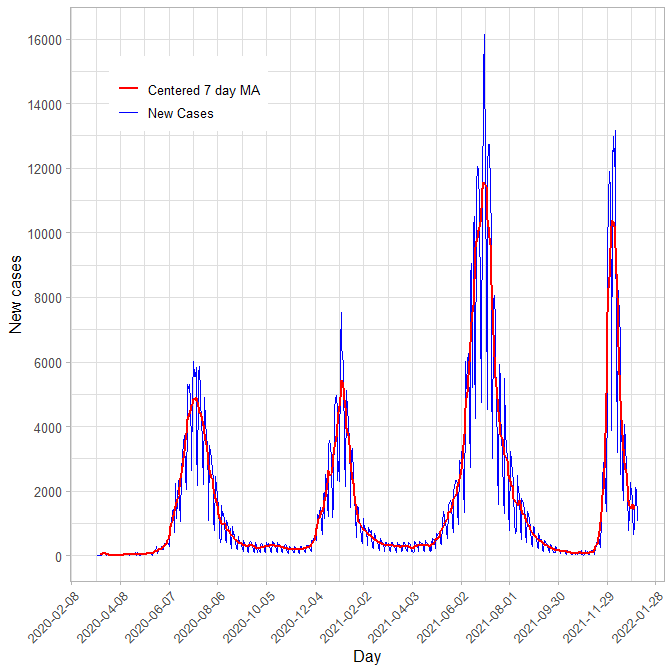

Figure 1: New Cases and their centered 7-day moving average for Gauteng province in South Africa between 10 March 2020 and 5 January 2022.

## Setting up the forecasting exercise

We begin by specifying a number of options for the forecasting exercise, as defined below.

- `Y` is the data, in the form of time series of cumulative confirmed cases. In this example the object holding this series is called `gauteng`.
- `estimation.date.start` is the date of the first observation in the sample to be used for estimating the model. By default, it is the first date in the `xts` object `Y`.
- `estimation.date.end` is the date of the last observation in the sample to be used for estimating the model. By default, it is the last date in the `xts` object `Y`.
- `n.forecasts` is the number of days or periods for which forecasts are to be made. E.g., if `n.forecasts = 14`, forecasts will be generated for up to 14 days following `estimation.date.end`.
- `q` is the signal-to-noise ratio, which controls the smoothness of the estimated trend. A lower value will lead to more smoothness. By default, we use `q = 0.005`, which in our experience ensures a good balance between the smoothness of the trend and the speed with which changes in estimates respond to new observations. Alongside, `q` can be estimated and compared with the default value.
- `confidence.level` sets the coverage of the confidence intervals for $\ln(g_t)$ which is then used to generate the prediction intervals for forecasts. Here, we use 0.68, corresponding to the probability that the forecast lies within one standard deviation of the point forecast.
- `plt.length` sets a truncation date to enhance the clarity of plots, e.g. showing only the last 30 days of the estimation sample. The date range for plotting can be set as `plt.length` days upto `estimation.date.end`.

In this example the data is the cumulative confirmed cases time series for Gauteng. The start and end dates (`estimation.date.start` and `estimation.date.end`) that define the sample used for estimation are chosen as appropriate for the exercise. In this example, we begin with the sample period set from 1 February to 19 April 2021. This marks the beginning of the third wave in Gauteng as can be seen in Figure 1. The options are specified as below.

```r
file.path = here()
res.dir <- here::here(file.path, 'results')
date.format <- "%Y-%m-%d"
Y = gauteng
estimation.date.start = as.Date("2021-02-01")
estimation.date.end = as.Date("2021-04-19")
n.forecasts = 14
q = 0.005
confidence.level = 0.68
plt.length = 30
```

## Estimation

We begin by selecting the data series (`Y`) for the defined sample period.

```r
idx.est =
    (zoo::index(Y) >= estimation.date.start) &
    (zoo::index(Y) <= estimation.date.end)
y = Y[idx.est]
```

We then estimate the model using a diffuse prior distribution for the initial state vector. The signal-to-noise ratio can be left as a free parameter to be estimated, as in the code below.

```r
model_q <- SSModelDynamicGompertz$new(Y = y)
res_q <- model_q$estimate()
```

In the rest of this example we estimate the model setting the signal-to-noise ratio at $0.005.$ As mentioned, in our experience this value strikes a useful balance between the smoothness of the estimate of the slope parameter $\gamma$, and the speed with which it adapts to new observations.

```r
model = SSModelDynamicGompertz$new(Y = y, q = q)
res = model$estimate()
```

## Results

We can now plot the forecast of $\ln g_t$ - the log of the growth rate of $Y$, the cumulative cases – which is the transformation of the data series that is taken to the model, and we can compare these forecasts to the actual $\ln g_t$ series. We do this by passing the output (`res`) of the estimation step along with an evaluation sample to a plotting function. We specify the evaluation sample by converting the cumulative cases series to the log of the growth rate of the cumulative cases.

`tsgc::plot_log_forecast` then creates and plots forecasts of $\ln(g_t)$.

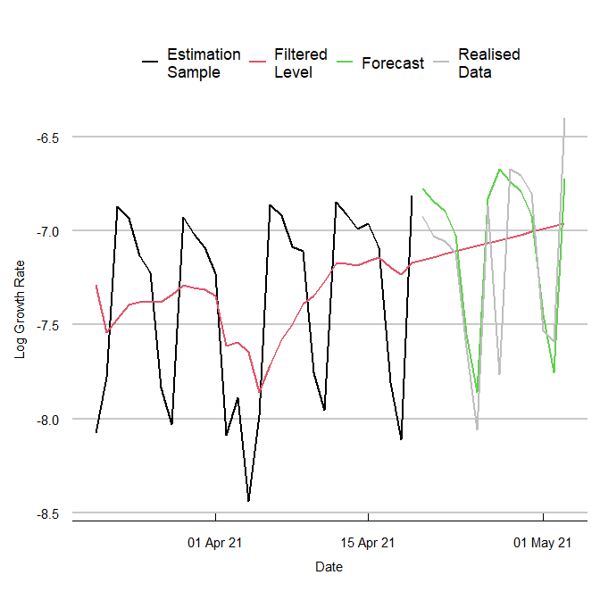

Figure 2: Fourteen-day forecast of ln(g_t) from 20 April 2021, for Gauteng province in South Africa.

```r
tsgc::plot_log_forecast(
  res = res,
  Y = Y,
  n.ahead = n.forecasts,
  plt.start.date = tail(res$index, 1) - plt.length
)
```

From these results we can recover the forecasts of new cases from 20 April 2021, with their prediction intervals.

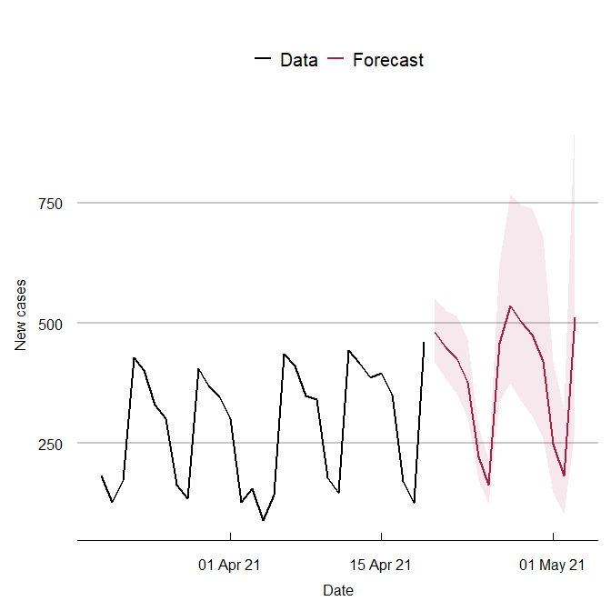

Figure 3: Fourteen-day forecast of new cases from 20 April 2021 for Gauteng province in South Africa

```r
tsgc::plot_forecast(
  res = res,
  n.ahead = n.forecasts,
  confidence.level = confidence.level,
  plt.start.date = tail(res$index, 1) - plt.length,
  series.name = "cases"
)
```

To assess accuracy, we plot these forecasts against the actual new cases, that have been held back from the estimation sample, using the `plot_holdout` function. The model forecasts are compared with the the first differences of `Y.eval`, the cumulative series for the forecast window.

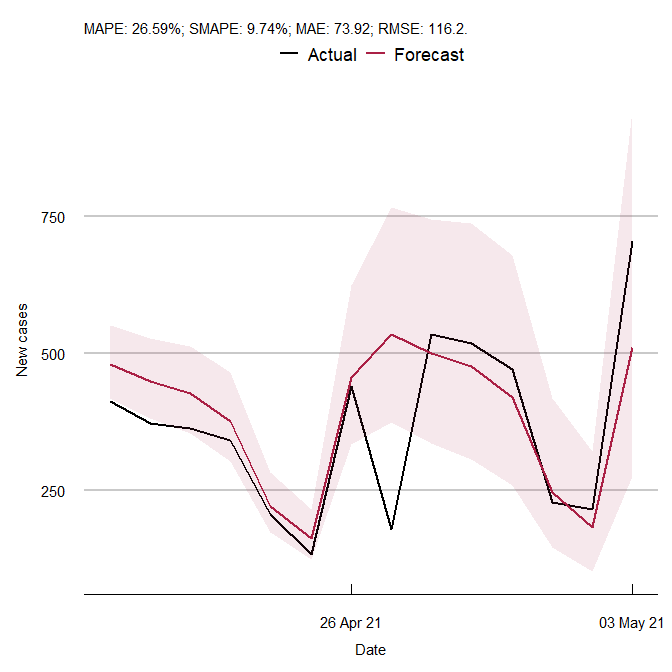

Figure 4: Accuracy of the fourteen-day forecast of new cases from 20 April 2021 for Gauteng province in South Africa.

```r
tsgc::plot_holdout(
  res = res,
  Y = Y,
  n.ahead = 14,
  confidence.level = 0.68,
  series.name = "cases"
)
```

Figure 4 shows that the forecasts were accurate over the first seven days, with a mean absolute percentage error (MAPE) of 13.9%. Note that reported cases were unusually low on 27 April due to the fact that it is Freedom Day and a public holiday in South Africa. That day aside, over the six days from 28 April the MAPE was 12.8%. Over the full 14 days of the forecasts, the MAPE was 27%.

As discussed earlier, the reproduction numbers $R_t$ and their 68% credible intervals can be calculated. The plot in Figure 5 reveals that $R_t$ remains above one through the period, indicating that the (third) wave in Gauteng had launched by this time.

```r
r.t <- tail(exp(res$get_gy_ci()*gen_int),7)
```

```
## # A tibble: 7 × 5
##   Date          Rt lower upper name
##   <date>     <dbl> <dbl> <dbl> <chr>
## 1 2021-04-13  1.18 1.05   1.34 Gauteng
## 2 2021-04-14  1.14 1.01   1.29 Gauteng
## 3 2021-04-15  1.13 1.01   1.28 Gauteng
## 4 2021-04-16  1.12 0.996  1.27 Gauteng
## 5 2021-04-17  1.06 0.941  1.20 Gauteng
## 6 2021-04-18  1.02 0.906  1.15 Gauteng
## 7 2021-04-19  1.06 0.944  1.20 Gauteng
```

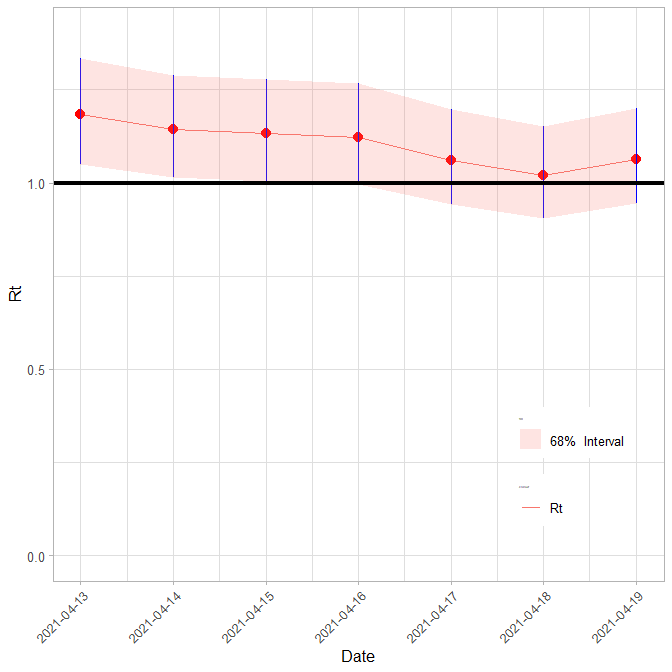

Figure 5: Reproduction numbers for the 7-day period to 19 April 2021, for Gauteng province in South Africa.

```r
tsgc::write_results(
 res=res,
 res.dir = res.dir,
 n.ahead = n.forecasts,
 confidence.level =  confidence.level
)
```

## Reinitialization

This section illustrates the reinitialization procedure which allows us to apply the model to the new wave as it begins, without jettisoning information from the wave that has just ended. We extend the estimation window to 25 June 2021, by which date the third wave is well on course with its peak within sight (see Figure 1). All other options remain the same.

```r
estimation.date.end = as.Date("2021-06-25")
```

### Triggering reinitialization

It is not obvious, a priori, when precisely to reinitialize the model. Based on experiments a reasonable option is to reinitialize when the estimate of the slope parameter, $\gamma_t$, breaches a threshold of two standard errors above zero, and at that point backdate reinitialization to when the estimate of $\gamma_t$ first turned positive. In applying the above heuristic there is a choice between the filtered slope estimate and the smoothed slope estimate. Experiments suggests that the greater noisiness of the filtered estimate of $\gamma_t$ often triggers reinitialization too early. The smoothed estimate is more reliable.

Figure 6 shows that for the third wave in Gauteng, the smoothed slope estimate exceeded twice its standard error on 1 May 2021, having risen above zero on 21 April 2021.

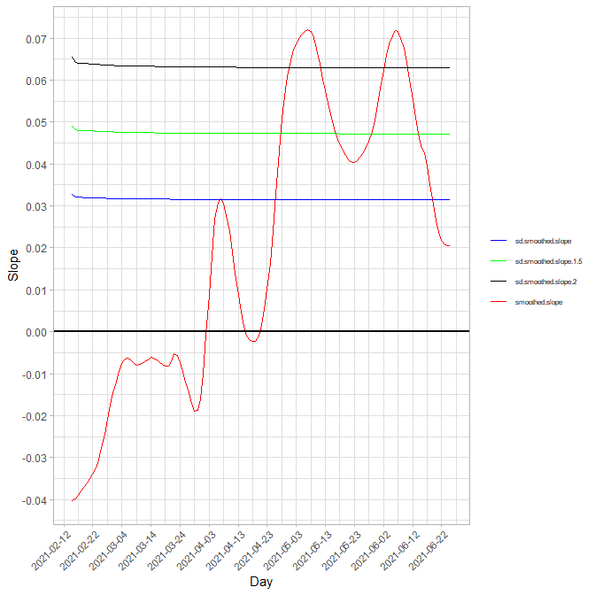

The date for reinitialization is set accordingly.

```r
reinit.dates = "2021-04-21"
```

### Estimating the reinitialized model

A reinitialized `SSModelDynamicGompertz` uses the same arguments as the non-reinitialized model, with the addition of the `reinit.date` argument.

```r
model <- SSModelDynamicGompertz$new(
  Y = y, q = q,
  reinit.date = as.Date(reinit.dates,
  format = date.format)
)
res.reinit <- model$estimate()
```

Estimating the model with the reinitialized series, the actual and forecast $\ln(g_t)$ can be plotted as in Figure 7, which is analogous to Figure 2 for the non-reinitialized series.

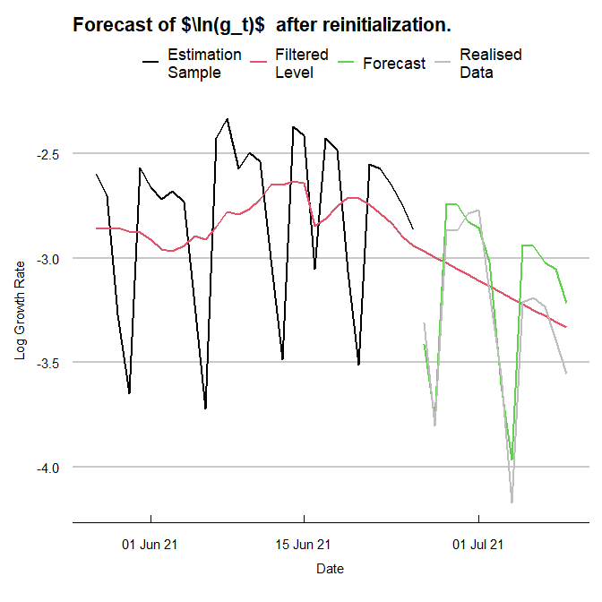

Figure 7: Forecast of ln(g_t) after reinitialization.

```r
tsgc::plot_log_forecast(
    res = res.reinit,
    Y = Y,
    n.ahead = n.forecasts,
    plt.start.date =  tail(res.reinit$index, 1) - plt.length,
    title='Forecast of $\\ln(g_t)$  after reinitialization.'
)
```

The plot of the forecasts of new cases, and that of these forecasts against the actual number of new cases can be produced as before. See Figures 8 and 9. The trend has begun to turn down in model forecasts with the reinitialized series.

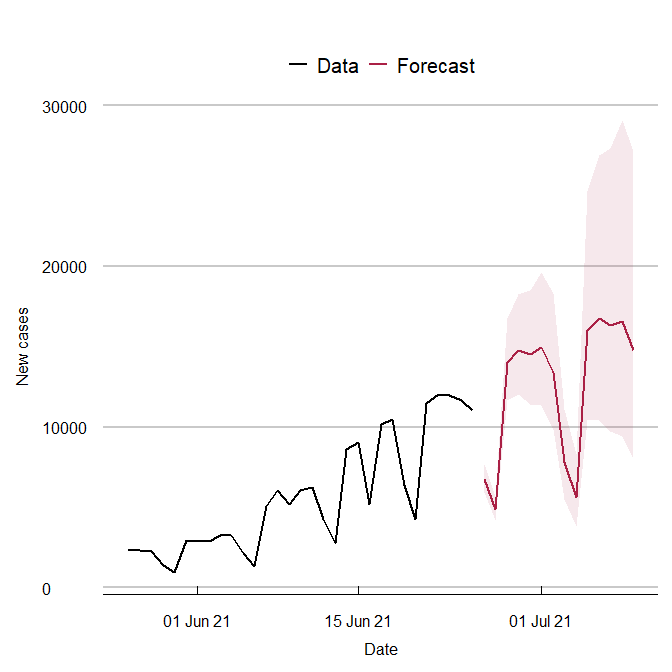

Figure 8: Forecast of new cases after reinitialization.

```r
tsgc::plot_forecast(
  res = res.reinit,
  n.ahead = n.forecasts,
  confidence.level = confidence.level,
  plt.start.date = tail(res.reinit$index, 1) - plt.length,
  series.name = "cases"
)
```

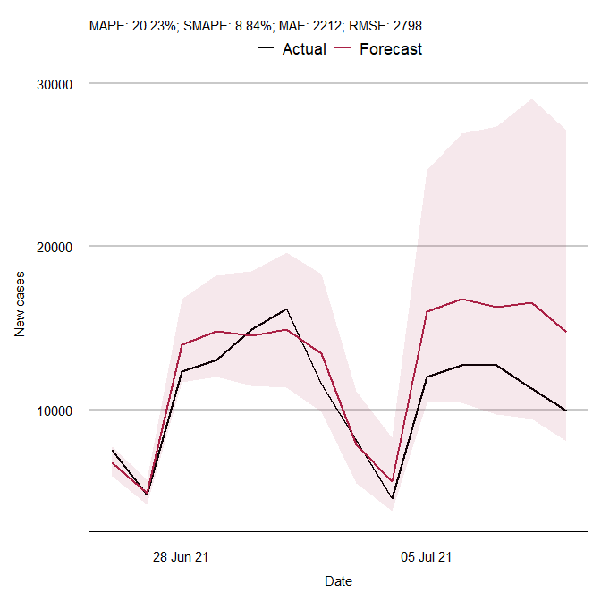

Figure 9: Forecast accuracy of the reinitialized model over the hold-out sample period: 14 days past 25 June 2021.

```r
tsgc::plot_holdout(
  res = res.reinit,
  Y = Y,
  n.ahead = 14,
  confidence.level = 0.68,
  series.name = "cases"
)
```

Comparing forecasts, without reinitialization the 14-day forecast MAPE is 41.9% (see Figure 10). With reinitialization, it falls to 20.2%. The corresponding MAPE figures for 7-day forecasts is 15.2% without reinitialization and 9.5% with reinitialization.

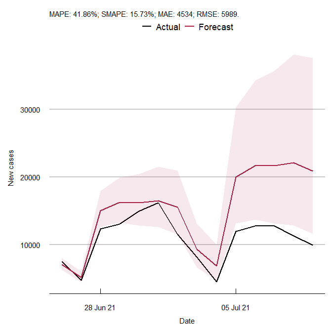

Figure 10: Forecast accuracy of the model without reinitialization over the hold-out sample period: 14 days from 25 June 2021.

Just as for the standard (non-reinitialized) model, the returned estimation results contained in `res.reinit` are a `FilterResults` object, and can be written to CSV using the `write_results` method.

# Conclusions

The `tsgc` package is based on a dynamic Gompertz curve model for the log of the growth rate of cumulative cases in an epidemic, with seasonal terms that capture day-of-the-week effects. The estimation is carried out using `KFAS`, a package for state-space modeling in `R`.

The Kalman filter is used to estimate the state vector at each time point. The filter is initialized using a diffuse prior for the initial state vector. We allow the signal-to-noise ratio to either be estimated or fixed at some value based on experience and judgment. Future observations are forecast using predictive recursions.

Epidemics are often characterized by multiple waves. A natural problem in this context is that there is very little data pertinent to the new wave available in its initial stages. The package employs a reinitialization method using priors in a way that allows data from before the beginning of the new wave to be used in estimation. The same framework can be extended to a leading-indicator formulation for outcomes that are preceded by an observable correlate, and it can be applied to data measured at different frequencies once the relevant seasonal period and lag structure are chosen.

The package is demonstrated using COVID-19 data from South Africa and England, but it can be used to model and forecast any time series variable where a growth curve-like trajectory is expected. Examples might include sales of a new product, innovation adoption or website traffic. The approach is phenomenological rather than mechanistic: it is designed for short-horizon forecasting and exploratory analysis rather than for causal identification or structural epidemiological inference. The forecast bands are state-implied summaries of the latent-state uncertainty and should not be interpreted as calibrated prediction or confidence intervals in the usual sense. In addition, the implied lead–lag relationship between a leading indicator and a target series can break down over time, so the model should be monitored and re-estimated as conditions change.

# Acknowledgements

We thank The Cambridge Centre for Health Leadership & Enterprise, University of Cambridge Judge Business School, and Public Health England/UK Health Security Agency for generous support. We are indebted to Thilo Klein and Stefan Scholtes for constructive comments. Andrew Harvey’s work was carried out as part of the University of Cambridge Keynes Fund project `Forecasting and Policy in Environmental Econometrics’.

# References

Abbott, Sam, and Pietro Monticone. 2021. “Epiforecasts/Epinowcast: Evaluation in Germany Initial Release,” November. https://doi.org/10.5281/zenodo.5637165.

Cori, Anne, Neil M. Ferguson, Christophe Fraser, and Simon Cauchemez. 2013. “A New Framework and Software to Estimate Time-Varying Reproduction Numbers During Epidemics.” *American Journal of Epidemiology* 178 (9): 1505–12. https://doi.org/10.1093/aje/kwt133.

Durbin, James, and Siem Jan Koopman. 2012. *Time Series Analysis by State Space Methods*. Oxford University Press.

Harvey, Andrew, and Paul Kattuman. 2020. “Time Series Models Based on Growth Curves with Applications to Forecasting Coronavirus.” *Harvard Data Science Review*.

———. 2021. “A Farewell to R: Time-Series Models for Tracking and Forecasting Epidemics.” *Journal of the Royal Society Interface* 18 (182): 20210179.

Harvey, Andrew, Paul Kattuman, and Craig Thamotheram. 2021. “Tracking the Mutant: Forecasting and Nowcasting COVID-19 in the UK in 2021.” *National Institute Economic Review* 256 (1): 110–26. https://www.cambridge.org/core/journals/national-institute-economic-review/article/tracking-the-mutant-forecasting-and-nowcasting-covid19-in-the-uk-in-2021/61A3E91B103E38D6ADA4BF5CC1E9CFC9.

Helske, Jouni. 2017. “KFAS: Exponential Family State Space Models in R.” *Journal of Statistical Software* 78 (i10).

Jenness, Samuel M, Steven M Goodreau, and Martina Morris. 2018. “EpiModel: An R Package for Mathematical Modeling of Infectious Disease over Networks.” *Journal of Statistical Software* 84.

Proietti, Tommaso. 2000. “Comparing Seasonal Components for Structural Time Series Models.” *International Journal of Forecasting* 16 (2): 247–60.

Wallinga, J., and M. Lipsitch. 2007. “How Generation Intervals Shape the Relationship Between Growth Rates and Reproductive Numbers.” *Proceedings of the Royal Society B* 274: 599–604.

# Appendix: Incorporating seasonal terms into the state space model

When we add a seasonal term to the model, the observation equation in the dynamic Gompertz curve (2) becomes
$$\ln
g_{t}=\delta_{t}+\nu_t+\varepsilon_{t},\;\;\;\;\;\varepsilon_{t}\sim
NID(0,\sigma_{\varepsilon }^{2}),\;\;\;\;\;t=s,...,T,$$
where $\nu_t$ is the seasonal component, $\delta_t$ remains defined by (3), and $\varepsilon_t$ remains the iid Normal disturbance.

There are two options for specifying the evolution of the seasonal component. We can either use a trigonometric seasonal or a dummy variable seasonal. In our application, we use a trigonometric seasonal, although the two specifications are closely related. Indeed, Proietti (2000) shows that, under certain conditions, the two approaches are equivalent.

In the trigonometric seasonal approach, the seasonal pattern is captured by a set of trigonometric terms at the seasonal frequencies $\lambda_j = \frac{2 \pi j}{2}$ for $j=1, \ldots s^*$, where $s^*=\frac{s}{2}$ if $s$, the periodicity of the seasonal effect, is even, and $s^*=\frac{s-1}{2}$ if $s$ is odd Durbin and Koopman (2012). Our applications use daily data and we set $s=7$ to capture day-of-the-week effects.

Letting $\nu_{j,t}$ be the effect of season $j$ at time $t$, the seasonal terms evolve according to

$$\begin{align}
\nu_{t} &= \sum_{j=1}^{s^{*}} \nu_{j,t}, & (13)
\end{align}$$

where
$$\begin{align}
\nu_{j,t} &= \nu_{j,t-1} \cos \lambda_j + \nu^*_{j,t-1} \sin
\lambda_j + \omega_{j,t} & (14)\\
\nu^*_{j,t} &= -\nu_{j,t-1} \sin \lambda_j + \nu^*_{j,t-1} \cos
\lambda_j + \omega^*_{j,t}, \;\;\;\;\; j = 1, \ldots, s^*, & (15)
\end{align}$$
and $\omega_{j,t}$ and $\omega^*_{j,t}$ are mutually independent, iid $N(0,\sigma^2_{\omega})$ variables.

When reinitializing the model with seasonal terms, $P^r_1$ is a block-diagonal matrix based on $P_{r+1}$ which sets the covariances between $(\delta_t,\gamma_t)'$ and $(\nu_{1,t},\nu_{2,t},\ldots,\nu_{s^*,t})'$ to be zero. The covariance between $\delta_t$ and $\gamma_t$, as well as the covariances between $\nu_{1,t},\nu_{2,t},\ldots,\nu_{s^*,t}$, are permitted to be non-zero and come directly from $P_{r+1}$.

[^1]: Of course, while $y_t$ denotes daily new cases here, it could equally denote weekly sales of a new product, etc. None of the analysis here is dependent on the data frequency.
[^2]: These are not proper prediction or confidence intervals for $y_{T+\ell}$. The one-step-ahead predictive distribution of $\hat{y}_{T+\ell|T}$ (for $\ell=1$) is lognormal. This is not the case more than one step ahead due to the presence of the cumulative total in equation (2).
[^3]: Note the change in sign of $\gamma$ as compared with HK.